## Introduction to R programming, final assignment: statistical analysis of the UFO sightings database

Space, the final frontier. These are my attempts at statistical analysis of the UFO sightings database of the National UFO Reporting Center. After the exploration of the dataset I investigated the relationship between the duration of the reported UFO sightings and both the shape of the reported object and the lighting conditions of the sighting using non-parametric statistical tests. The results showed a significantly shorter sighting duration for “fireball” shaped objects, and a significant difference between the sighting durations during the night and by daylight.

### The dataset

I explored the “UFO sightings” dataset downloaded from kaggle, provided by the National UFO Reporting Center. I used the “scrubbed” version of the dataset, which does not include reports with missing locations and dates. It contains 80332 UFO sighting reports from the last century in a long-format dataset. The variables including information about the individual UFO sightings in the original dataset are datetime (day/month/year hour:minute), city, state, country, shape, duration (seconds), duration (hours/min), comments, date posted, latitude and longitude.

### Exploratory data analysis

To explore the data, first I determined the number of missing values in both the whole dataset and by column. There were overall 17680 missing vales, 5797 in state, 9670 in country, 1932 in shape and 265 in duration (second).

```
## [1] 17680
```

```
##             datetime                 city                state
##                    0                    0                 5797
##              country                shape   duration (seconds)
##                 9670                 1932                  265
## duration (hours/min)             comments          date posted
##                    0                   15                    0
##             latitude            longitude
##                    1                    0
```

I tidied the data by removing the missing values, renaming the duration variables (into duration_s and duration_hm) and separating the datetime variable into year, month, day, hour and mins (minutes). I wanted to focus on the sightings from the USA in my analysis, so I filtered the data for that country.

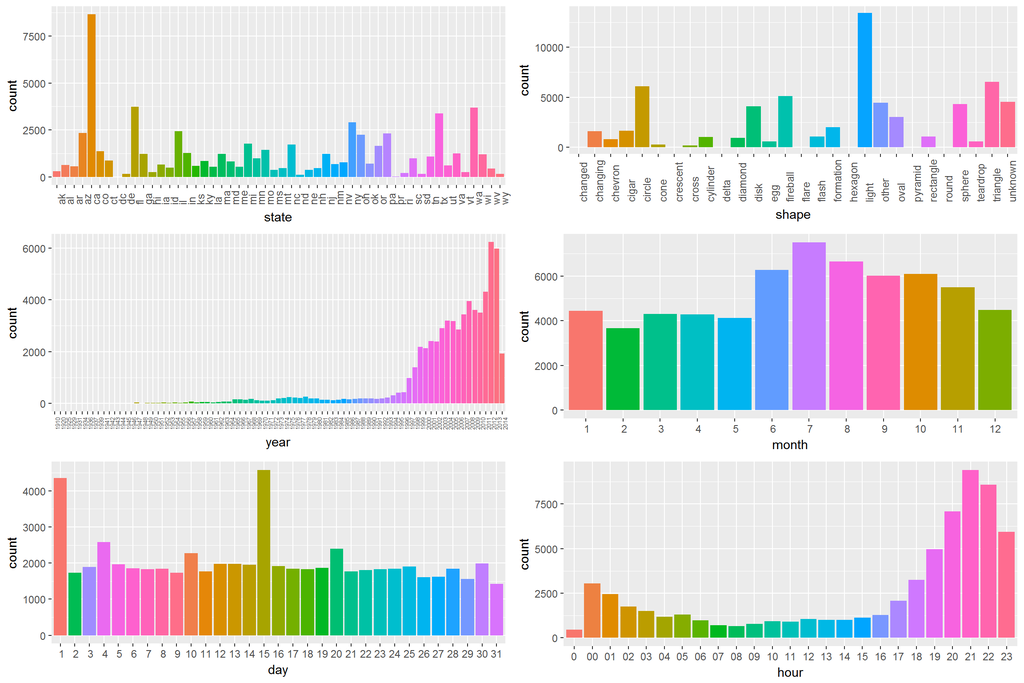

The only continuous variable in the dataset was duration_s (duration in seconds). Since it ranged from a couple of seconds to several years (with a mean of ~5546 s, a median of 180 s, a minimum of 1 s and maximum of 66276000 s), instead of presenting it on a histogram I decided to create duration groups (duration_group) to be able to visualize the data. The bar chart of the grouped duration data shows that it is very rare for a UFO sighting to last more 5 hours, and most of them continue for less than 30 minutes, usually only a couple of seconds or minutes.

```
## # A tibble: 1 x 7
##       mean       sd     variance median   iqr   min      max
##      <dbl>    <dbl>        <dbl>  <int> <dbl> <dbl>    <dbl>
## 1 5545.833 407267.5 165866834088    180   570     1 66276000
```

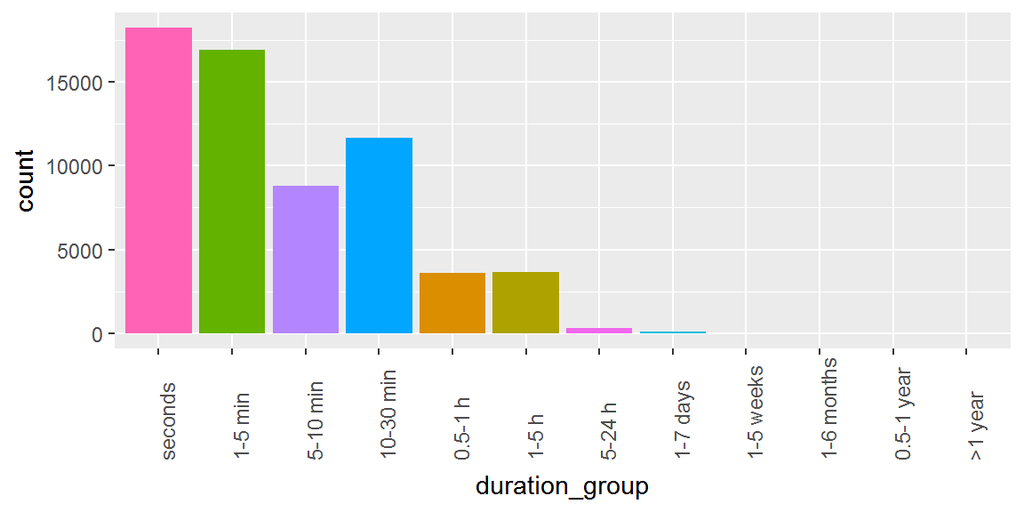

For the following part of analysis I used the data that have sighting duration of less than 30 minutes (1800 seconds). I illustrated the distribution of that portion of the duration data with a histogram, which shows a non-normal distribution, and certain values are present more frequently (most of them probably rounded to 5-10-15 minutes).

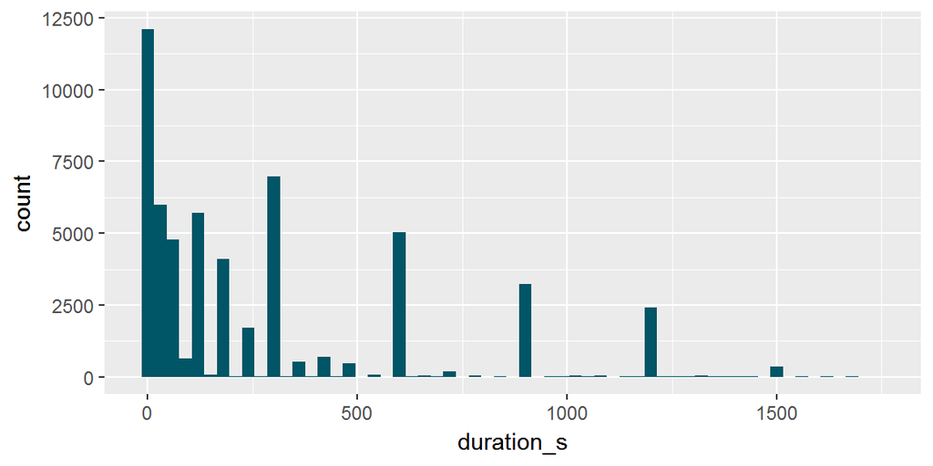

In the next section I investigated the possible relationship between the duration of the sightings and two other factors, the reported shape of the UFO and the lighting conditions og the sighting.

### Hypotheses and modeling

#### UFO shape and sighting duration

People reported a large number of UFOs with a number of very different shapes. Regardles of the true origins of these objects, they probably differ in many of their properties, one might be that how loght are they are staying in one place or in a visible distance from the ground.

To investigate whether different shapes of UFOs are seen for different durations, I compared the 4 most commonly reported shapes (circle, fireball, light and triangle - all described in more than 5000 accounts) using their sighting durations. My hypothesis was that since two of these commonly seen shapes are only lights, and nothing about the shape of the object is revealed, the sightings would be shorter as well, because short sightings would end in less detailed reports.

Due to the dependent variable (duration_s) not being normally distributed, and the assumption of homogenity of variance of the planned analysis being violated (K2(3) = 247.07, p<0.001), I used a non-parametric Kruskal_Wallis test to test my hypothesis. The Kruskal-Wallis test showed a significant difference between the four shapes (circle: Med=120, IQR=315; fireball: Med=120, IQR=290;light: Med=120, IQR=330; triangle: Med=120, IQR=270; H(3)= 267.09, p<.001). The post-hoc analysis consisting of separate Mann-Whitney U tests showed significantly lower duration for fireball shaped UFOs compared to all other shapes (p values were all < 0.001).

```
##
##  Bartlett test of homogeneity of variances
##
## data:  duration_s by shape
## Bartlett's K-squared = 247.07, df = 3, p-value < 2.2e-16
```

```
## # A tibble: 4 x 5
##      shape `median(duration_s)` `IQR(duration_s)` `min(duration_s)`
##     <fctr>                <dbl>             <dbl>             <dbl>
## 1   circle                  120               315                 1
## 2 fireball                  120               290                 1
## 3    light                  120               330                 1
## 4 triangle                  120               270                 1
## # ... with 1 more variables: `max(duration_s)` <dbl>
```

```
##
##  Kruskal-Wallis rank sum test
##
## data:  duration_s by shape
## Kruskal-Wallis chi-squared = 267.09, df = 3, p-value < 2.2e-16
```

```
##
##  Pairwise comparisons using Wilcoxon rank sum test
##
## data:  data_shape$duration_s and data_shape$shape
##
##          circle fireball light
## fireball <2e-16 -        -
## light    0.94   <2e-16   -
## triangle 1.00   <2e-16   1.00
##
## P value adjustment method: bonferroni
```

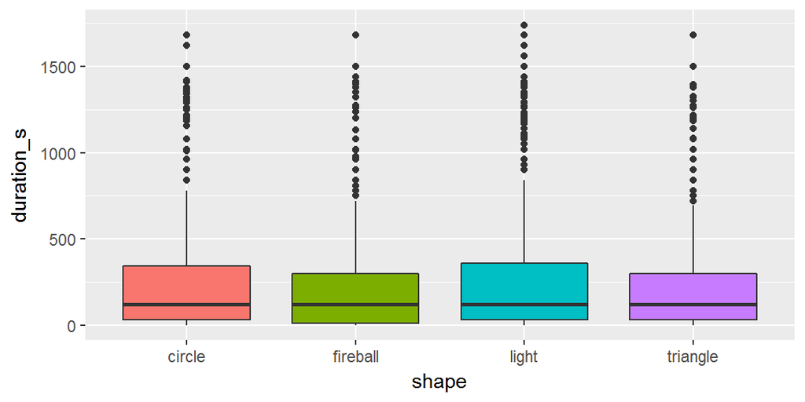

#### Lighting conditions and duration of sighting

```
## # A tibble: 2 x 5
##   light_dark `median(duration_s)` `IQR(duration_s)` `min(duration_s)`
##       <fctr>                <dbl>             <dbl>             <dbl>
## 1       dark                  120               280                 1
## 2      light                  120               270                 1
## # ... with 1 more variables: `max(duration_s)` <dbl>
```

```
##
##  Wilcoxon rank sum test with continuity correction
##
## data:  duration_s by light_dark
## W = 128330000, p-value = 0.003331
## alternative hypothesis: true location shift is not equal to 0
```

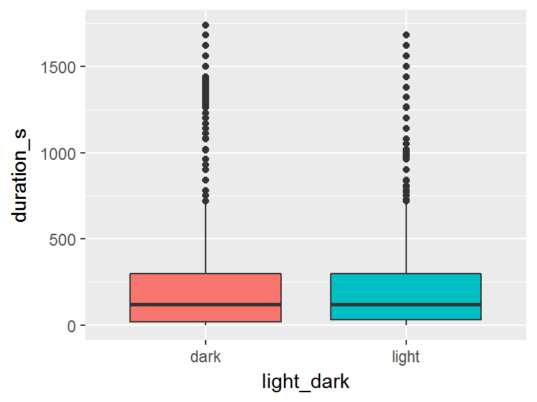

### Conclusions

The statistical analysis of the relationship between the duration of the UFO sightings and the shape of the object showed that one of the most commonly reported shape, “fireball” is observed for significantly shorter durations, than other objects. Since people could describe a moving light-source as a fireball, this result could be explained by this shape being reported for most fast-moving objects. The duration of the sighting was also different for the dark and sunlit periods of that day, but the direction of this difference is not that easily discernable. The sightings being slightly longer in the darker hours of the day could be explained by the emitted light of the objects being more salient.

These observations are most probably the consequences of human factors and not the preferences of alien life for luring in the dark and making quick detours on fireball-shaped spaceships. But regardless, the truth might be still out there.

[figure not shown]